# ExtraaLearn Project

## Context

The EdTech industry has been surging in the past decade immensely, and according to a forecast, the Online Education market would be worth $286.62bn by 2023 with a compound annual growth rate (CAGR) of 10.26% from 2018 to 2023. The modern era of online education has enforced a lot in its growth and expansion beyond any limit. Due to having many dominant features like ease of information sharing, personalized learning experience, transparency of assessment, etc, it is now preferable to traditional education.

In the present scenario due to the Covid-19, the online education sector has witnessed rapid growth and is attracting a lot of new customers. Due to this rapid growth, many new companies have emerged in this industry. With the availability and ease of use of digital marketing resources, companies can reach out to a wider audience with their offerings. The customers who show interest in these offerings are termed as leads. There are various sources of obtaining leads for Edtech companies, like

- The customer interacts with the marketing front on social media or other online platforms.
- The customer browses the website/app and downloads the brochure
- The customer connects through emails for more information.

The company then nurtures these leads and tries to convert them to paid customers. For this, the representative from the organization connects with the lead on call or through email to share further details.

## Objective

ExtraaLearn is an initial stage startup that offers programs on cutting-edge technologies to students and professionals to help them upskill/reskill. With a large number of leads being generated on a regular basis, one of the issues faced by ExtraaLearn is to identify which of the leads are more likely to convert so that they can allocate resources accordingly. You, as a data scientist at ExtraaLearn, have been provided the leads data to:

- Analyze and build an ML model to help identify which leads are more likely to convert to paid customers,
- Find the factors driving the lead conversion process
- Create a profile of the leads which are likely to convert

## Data Description

The data contains the different attributes of leads and their interaction details with ExtraaLearn. The detailed data dictionary is given below.

**Data Dictionary**

- ID: ID of the lead
- age: Age of the lead
- current_occupation: Current occupation of the lead. Values include 'Professional','Unemployed',and 'Student'
- first_interaction: How did the lead first interacted with ExtraaLearn. Values include 'Website', 'Mobile App'
- profile_completed: What percentage of profile has been filled by the lead on the website/mobile app. Values include Low - (0-50%), Medium - (50-75%), High (75-100%)
- website_visits: How many times has a lead visited the website
- time_spent_on_website: Total time spent on the website
- page_views_per_visit: Average number of pages on the website viewed during the visits.
- last_activity: Last interaction between the lead and ExtraaLearn.
  - Email Activity: Seeking for details about program through email, Representative shared information with lead like brochure of program , etc
  - Phone Activity: Had a Phone Conversation with representative, Had conversation over SMS with representative, etc
  - Website Activity: Interacted on live chat with representative, Updated profile on website, etc
- print_media_type1: Flag indicating whether the lead had seen the ad of ExtraaLearn in the Newspaper.
- print_media_type2: Flag indicating whether the lead had seen the ad of ExtraaLearn in the Magazine.
- digital_media: Flag indicating whether the lead had seen the ad of ExtraaLearn on the digital platforms.
- educational_channels: Flag indicating whether the lead had heard about ExtraaLearn in the education channels like online forums, discussion threads, educational websites, etc.
- referral: Flag indicating whether the lead had heard about ExtraaLearn through reference.
- status: Flag indicating whether the lead was converted to a paid customer or not.

## Importing necessary libraries and data

```python
# import libraries for data manipulation
import numpy as np
import pandas as pd

# import libraries for data visualization
import matplotlib.pyplot as plt
import seaborn as sns
sns.set()

# import the library for probability/statistics
import scipy.stats as stats

# import ML models we require from Scikit-Learn
from sklearn.linear_model import LogisticRegression
from sklearn.svm import SVC
from sklearn.tree import DecisionTreeClassifier
from sklearn import tree
from sklearn.ensemble import RandomForestClassifier

# import other relevent functions from Scikit-Learn
from sklearn.model_selection import train_test_split, GridSearchCV
from sklearn.preprocessing import MinMaxScaler, LabelEncoder, OneHotEncoder
from sklearn.impute import SimpleImputer
from sklearn.metrics import confusion_matrix,classification_report,roc_auc_score,precision_recall_curve,roc_curve,make_scorer

# to suppress warnings
import warnings
warnings.filterwarnings('ignore')
```

```python
# connect to Google Drive
from google.colab import drive
drive.mount('/content/drive')
```

```python
# read the data
data = pd.read_csv('/content/drive/MyDrive/Colab-Notebooks/ExtraaLearn.csv')
```

## Data Overview

- Observations
- Sanity checks

```python
# returning the first 5 rows
data.head()
```

|  | ID | age | current_occupation | first_interaction | profile_completed | website_visits | time_spent_on_website | page_views_per_visit | last_activity | print_media_type1 | print_media_type2 | digital_media | educational_channels | referral | status |
| --- | --- | --- | --- | --- | --- | --- | --- | --- | --- | --- | --- | --- | --- | --- | --- |
| 0 | EXT001 | 57 | Unemployed | Website | High | 7 | 1639 | 1.861 | Website Activity | Yes | No | Yes | No | No | 1 |
| 1 | EXT002 | 56 | Professional | Mobile App | Medium | 2 | 83 | 0.320 | Website Activity | No | No | No | Yes | No | 0 |
| 2 | EXT003 | 52 | Professional | Website | Medium | 3 | 330 | 0.074 | Website Activity | No | No | Yes | No | No | 0 |
| 3 | EXT004 | 53 | Unemployed | Website | High | 4 | 464 | 2.057 | Website Activity | No | No | No | No | No | 1 |
| 4 | EXT005 | 23 | Student | Website | High | 4 | 600 | 16.914 | Email Activity | No | No | No | No | No | 0 |

```python
# returning the last 5 rows
data.tail()
```

|  | ID | age | current_occupation | first_interaction | profile_completed | website_visits | time_spent_on_website | page_views_per_visit | last_activity | print_media_type1 | print_media_type2 | digital_media | educational_channels | referral | status |
| --- | --- | --- | --- | --- | --- | --- | --- | --- | --- | --- | --- | --- | --- | --- | --- |
| 4607 | EXT4608 | 35 | Unemployed | Mobile App | Medium | 15 | 360 | 2.170 | Phone Activity | No | No | No | Yes | No | 0 |
| 4608 | EXT4609 | 55 | Professional | Mobile App | Medium | 8 | 2327 | 5.393 | Email Activity | No | No | No | No | No | 0 |
| 4609 | EXT4610 | 58 | Professional | Website | High | 2 | 212 | 2.692 | Email Activity | No | No | No | No | No | 1 |
| 4610 | EXT4611 | 57 | Professional | Mobile App | Medium | 1 | 154 | 3.879 | Website Activity | Yes | No | No | No | No | 0 |
| 4611 | EXT4612 | 55 | Professional | Website | Medium | 4 | 2290 | 2.075 | Phone Activity | No | No | No | No | No | 0 |

#### Observations:

The DataFrame has 15 columns, which makes sense, given that there are 15 variables listed within the data dictionary. Each row has both a unique ID in the column "ID" in addition to the index value. Data in each row corresponds to an identified lead. It appears that the IDs of the leads are listed in ascending order from EXT001 (at index 0) to EXT4612 (at index 4611).

```python
# checking the shape of the dataset
data.shape
```

```
(4612, 15)
```

- There are 4,612 rows and 15 columns within the dataset.

```python
# checking for any missing values
data.isna().sum()
```

```
ID                       0
age                      0
current_occupation       0
first_interaction        0
profile_completed        0
website_visits           0
time_spent_on_website    0
page_views_per_visit     0
last_activity            0
print_media_type1        0
print_media_type2        0
digital_media            0
educational_channels     0
referral                 0
status                   0
dtype: int64
```

- There are no null values in this dataset.

```python
# checking the information summary of the DataFrame
data.info()
```

```
<class 'pandas.core.frame.DataFrame'>
RangeIndex: 4612 entries, 0 to 4611
Data columns (total 15 columns):
 #   Column                 Non-Null Count  Dtype
---  ------                 --------------  -----
 0   ID                     4612 non-null   object
 1   age                    4612 non-null   int64
 2   current_occupation     4612 non-null   object
 3   first_interaction      4612 non-null   object
 4   profile_completed      4612 non-null   object
 5   website_visits         4612 non-null   int64
 6   time_spent_on_website  4612 non-null   int64
 7   page_views_per_visit   4612 non-null   float64
 8   last_activity          4612 non-null   object
 9   print_media_type1      4612 non-null   object
 10  print_media_type2      4612 non-null   object
 11  digital_media          4612 non-null   object
 12  educational_channels   4612 non-null   object
 13  referral               4612 non-null   object
 14  status                 4612 non-null   int64
dtypes: float64(1), int64(4), object(10)
memory usage: 540.6+ KB
```

#### Observations:

- All columns have 4,612 observations, meaning that there are no null values.
- All variables have data types of either objects, inegers, or floats.
- The following data types should be converted into the categorical datatype: "current_occupation", "first_interaction", "profile_completed", "last_activity", "print_media_type1", "print_media_type2", "digital_media", educational_channels", "referral", and "status".

```python
# checking the number of unique values in each column
data.nunique()
```

```
ID                       4612
age                        46
current_occupation          3
first_interaction           2
profile_completed           3
website_visits             27
time_spent_on_website    1623
page_views_per_visit     2414
last_activity               3
print_media_type1           2
print_media_type2           2
digital_media               2
educational_channels        2
referral                    2
status                      2
dtype: int64
```

- We can drop the column "ID" since it is unique for each lead and will not add value to the model.

```python
# dropping the ID column
data.drop(columns='ID',inplace=True)
```

```python
# Converting status datatype to string
data['status'] = data['status'].apply(str)

# replacing '0' with 'Unpaid Customer' and '1' with 'Paid Customer' in 'status' column
data.status = data.status.replace('0', 'Unpaid Customer')
data.status = data.status.replace('1', 'Paid Customer')
```

```python
# checking whether the 'status' column values has been updated
print(data.status.value_counts()) # printing the count of the status column
```

```
Unpaid Customer    3235
Paid Customer      1377
Name: status, dtype: int64
```

```python
# investigating categorical variables
categorical = ["current_occupation", "first_interaction", "profile_completed", "last_activity", "print_media_type1", "print_media_type2", "digital_media", "educational_channels", "referral", "status"] # making a list of all categorical variables

# using a for-loop to adjust and assess the categorical columns
for column in categorical:
    data[column] = data[column].astype('category') # converting each column to categorical datatype
    print(data[column].value_counts()) # printing the count of each unique value per column

    print('-' * 50)
```

```
Professional    2616
Unemployed      1441
Student          555
Name: current_occupation, dtype: int64
--------------------------------------------------
Website       2542
Mobile App    2070
Name: first_interaction, dtype: int64
--------------------------------------------------
High      2264
Medium    2241
Low        107
Name: profile_completed, dtype: int64
--------------------------------------------------
Email Activity      2278
Phone Activity      1234
Website Activity    1100
Name: last_activity, dtype: int64
--------------------------------------------------
No     4115
Yes     497
Name: print_media_type1, dtype: int64
--------------------------------------------------
No     4379
Yes     233
Name: print_media_type2, dtype: int64
--------------------------------------------------
No     4085
Yes     527
Name: digital_media, dtype: int64
--------------------------------------------------
No     3907
Yes     705
Name: educational_channels, dtype: int64
--------------------------------------------------
No     4519
Yes      93
Name: referral, dtype: int64
--------------------------------------------------
Unpaid Customer    3235
Paid Customer      1377
Name: status, dtype: int64
--------------------------------------------------
```

- Each of the categorical variables only contain observations that align with the options provided in the data description.

```python
# checking whether the DataFrame has been updated
data.info()
```

```
<class 'pandas.core.frame.DataFrame'>
RangeIndex: 4612 entries, 0 to 4611
Data columns (total 14 columns):
 #   Column                 Non-Null Count  Dtype
---  ------                 --------------  -----
 0   age                    4612 non-null   int64
 1   current_occupation     4612 non-null   category
 2   first_interaction      4612 non-null   category
 3   profile_completed      4612 non-null   category
 4   website_visits         4612 non-null   int64
 5   time_spent_on_website  4612 non-null   int64
 6   page_views_per_visit   4612 non-null   float64
 7   last_activity          4612 non-null   category
 8   print_media_type1      4612 non-null   category
 9   print_media_type2      4612 non-null   category
 10  digital_media          4612 non-null   category
 11  educational_channels   4612 non-null   category
 12  referral               4612 non-null   category
 13  status                 4612 non-null   category
dtypes: category(10), float64(1), int64(3)
memory usage: 190.5 KB
```

- The intended variables have been successfully converted to a categorical datatype.
- There are now 14 columns in the DataFrame, since ID has been removed.

```python
# preliminary understaning the summary statistics of the numerical variables
data.describe().T
```

|  | count | mean | std | min | 25% | 50% | 75% | max |
| --- | --- | --- | --- | --- | --- | --- | --- | --- |
| age | 4612.0 | 46.201214 | 13.161454 | 18.0 | 36.00000 | 51.000 | 57.00000 | 63.000 |
| website_visits | 4612.0 | 3.566782 | 2.829134 | 0.0 | 2.00000 | 3.000 | 5.00000 | 30.000 |
| time_spent_on_website | 4612.0 | 724.011275 | 743.828683 | 0.0 | 148.75000 | 376.000 | 1336.75000 | 2537.000 |
| page_views_per_visit | 4612.0 | 3.026126 | 1.968125 | 0.0 | 2.07775 | 2.792 | 3.75625 | 18.434 |

- "age" ranges from 18 to 63 with a median of 51 and a mean of ~46 with a standard deviation of ~13
- "website_visits" ranges from 0 to 30 with a median of 3 and a mean of ~4 with a standard deviation of ~3
- "time_spent_on_website" ranges from 0 seconds to 2537 seconds with a median of 376 seconds and a mean of ~724 with a standard deviation of ~744
  - Time in seconds is difficult to comprehend. This column will need to be transformed so that this data is shown in minutes.
- "page_views_per_visit" ranges from 0 to ~18.4 with a median of ~2.8 and a mean of ~3.0 with a standard deviation of ~2.0

```python
# dividing each value in "time_spent_on_website" by 60 to convert from seconds to minutes
data.time_spent_on_website = data.time_spent_on_website.div(60)
```

```python
# investigating updated summary for "time_spent_on_website"
data.describe().T
```

|  | count | mean | std | min | 25% | 50% | 75% | max |
| --- | --- | --- | --- | --- | --- | --- | --- | --- |
| age | 4612.0 | 46.201214 | 13.161454 | 18.0 | 36.000000 | 51.000000 | 57.000000 | 63.000000 |
| website_visits | 4612.0 | 3.566782 | 2.829134 | 0.0 | 2.000000 | 3.000000 | 5.000000 | 30.000000 |
| time_spent_on_website | 4612.0 | 12.066855 | 12.397145 | 0.0 | 2.479167 | 6.266667 | 22.279167 | 42.283333 |
| page_views_per_visit | 4612.0 | 3.026126 | 1.968125 | 0.0 | 2.077750 | 2.792000 | 3.756250 | 18.434000 |

### **Summary:**

Several sanity checks have been performed, and preliminary analysis of the DataFrame has occurred. After these checks and some slight modifications, the DataFrame is better prepared for further analysis.

## Exploratory Data Analysis (EDA)

- EDA is an important part of any project involving data.
- It is important to investigate and understand the data better before building a model with it.
- A few questions have been mentioned below which will help you approach the analysis in the right manner and generate insights from the data.
- A thorough analysis of the data, in addition to the questions mentioned below, should be done.

**Questions**

1. Leads will have different expectations from the outcome of the course and the current occupation may play a key role in getting them to participate in the program. Find out how current occupation affects lead status.
2. The company's first impression on the customer must have an impact. Do the first channels of interaction have an impact on the lead status?
3. The company uses multiple modes to interact with prospects. Which way of interaction works best?
4. The company gets leads from various channels such as print media, digital media, referrals, etc. Which of these channels have the highest lead conversion rate?
5. People browsing the website or mobile application are generally required to create a profile by sharing their personal data before they can access additional information. Does having more details about a prospect increase the chances of conversion?

```python
# making a copy of the dataset for EDA to minimize risk of data loss
df = data.copy()
```

### Univarite Analysis - Numerical Variables

```python
# defining the hist_box() function with a boxplot and histogram within the same visual
def hist_box(data, col):
    f, (ax_box, ax_hist) = plt.subplots(2, sharex=True, gridspec_kw={'height_ratios': (0.15, 0.85)}, figsize=(12, 6))
    sns.boxplot(data=data, x=col, ax=ax_box, showmeans=True) # adding a boxplot
    sns.histplot(data=data, x=col, kde=True, ax=ax_hist) # adding a histogram
    plt.show()
```

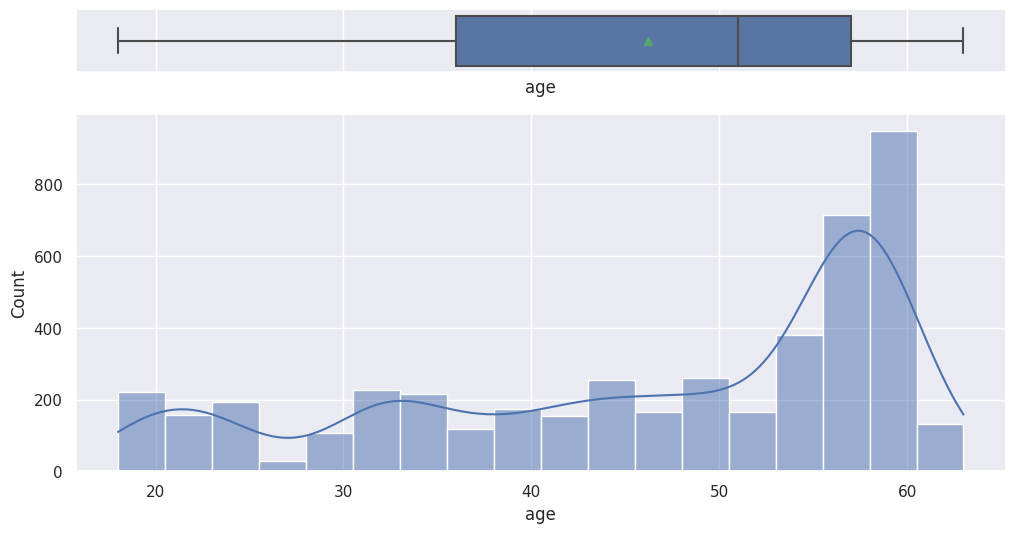

```python
# univariate analysis for "age" variable
hist_box(df,'age')
```

Observations

- The distribution of the "age" parameter is left-skewed.
- The boxplot confirms that there are no outliers in the "age" variable.

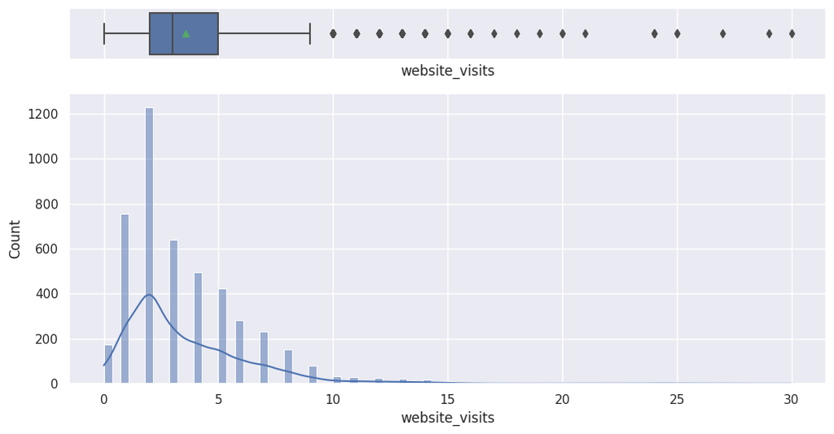

```python
# univariate analysis for "website_visits" variable
hist_box(df,'website_visits')
```

Observations

- The distribution of the "webite_visits" parameter is right-skewed.
- There are several data points in the region on the right of the boxplot that may be considered outliers. To investigate, we will look at how many extreme values there are.

```python
# finding the value count of each quantity of website visits
df.website_visits.value_counts(normalize=True)
```

```
2     0.266479
1     0.163703
3     0.138985
4     0.107112
5     0.091500
6     0.061145
7     0.050304
0     0.037728
8     0.032741
9     0.016912
10    0.007372
11    0.006288
12    0.005421
13    0.004987
14    0.003686
15    0.001951
24    0.000650
16    0.000650
25    0.000434
20    0.000434
30    0.000217
18    0.000217
27    0.000217
21    0.000217
17    0.000217
19    0.000217
29    0.000217
Name: website_visits, dtype: float64
```

- The table above shows that ~68% of leads had between 1 and 4 website visits.
- Generally, as the number of website visits increases, the percentage of leads decreases.
- Most data points appear to be between 0 and 15 website visits; however, there are no significant drops in these percentages, and the decrease in the amount of leads as the amount of website views increases appears to be a gradual taper.
- Thus, these "extreme values" are likely due to natural variations and should not be removed from the data set.

```python
# checking amount of data points with greater than 15 website visits
df[df.website_visits>15]
```

|  | age | current_occupation | first_interaction | profile_completed | website_visits | time_spent_on_website | page_views_per_visit | last_activity | print_media_type1 | print_media_type2 | digital_media | educational_channels | referral | status |
| --- | --- | --- | --- | --- | --- | --- | --- | --- | --- | --- | --- | --- | --- | --- |
| 66 | 59 | Unemployed | Mobile App | Medium | 25 | 5.183333 | 2.184 | Phone Activity | No | No | Yes | No | No | Unpaid Customer |
| 452 | 24 | Student | Mobile App | Low | 24 | 2.283333 | 6.814 | Email Activity | No | No | No | No | No | Unpaid Customer |
| 509 | 24 | Student | Mobile App | Medium | 30 | 6.466667 | 3.566 | Website Activity | No | No | No | No | No | Unpaid Customer |
| 1045 | 60 | Professional | Website | Medium | 16 | 34.533333 | 9.058 | Email Activity | Yes | No | Yes | Yes | No | Paid Customer |
| 1067 | 57 | Professional | Website | High | 18 | 6.183333 | 3.783 | Website Activity | Yes | No | No | No | No | Unpaid Customer |
| 1569 | 55 | Professional | Mobile App | Medium | 20 | 0.550000 | 3.048 | Phone Activity | Yes | No | No | No | No | Unpaid Customer |
| 1759 | 20 | Student | Website | High | 27 | 6.950000 | 2.071 | Email Activity | No | No | No | No | No | Unpaid Customer |
| 1933 | 56 | Professional | Website | Medium | 25 | 11.300000 | 3.804 | Email Activity | No | No | No | No | No | Paid Customer |
| 2192 | 40 | Professional | Website | Low | 21 | 3.600000 | 2.252 | Email Activity | No | No | No | No | No | Unpaid Customer |
| 2549 | 33 | Professional | Mobile App | Medium | 16 | 6.116667 | 2.401 | Email Activity | No | No | No | No | No | Unpaid Customer |
| 2642 | 56 | Professional | Website | High | 17 | 27.100000 | 2.236 | Website Activity | No | No | No | No | No | Paid Customer |
| 2673 | 56 | Professional | Mobile App | Medium | 19 | 5.500000 | 2.186 | Email Activity | No | No | No | Yes | No | Unpaid Customer |
| 2694 | 20 | Student | Mobile App | Medium | 29 | 19.200000 | 3.868 | Phone Activity | No | No | No | Yes | No | Unpaid Customer |
| 3809 | 47 | Unemployed | Website | High | 20 | 4.050000 | 2.011 | Email Activity | No | No | No | No | No | Unpaid Customer |
| 3862 | 58 | Professional | Website | High | 24 | 6.166667 | 2.159 | Phone Activity | No | No | No | No | No | Unpaid Customer |
| 4583 | 49 | Professional | Website | Medium | 24 | 17.316667 | 2.064 | Email Activity | Yes | No | No | No | No | Paid Customer |
| 4589 | 21 | Student | Website | High | 16 | 4.183333 | 2.108 | Phone Activity | No | No | No | No | No | Unpaid Customer |

Oberservations:

- There are 17 data points that have greater than 15 website visits, which is not an insignificant amount of leads.
- This information supports the decision to not remove any potential outliers from the "website_visits" column in this case.

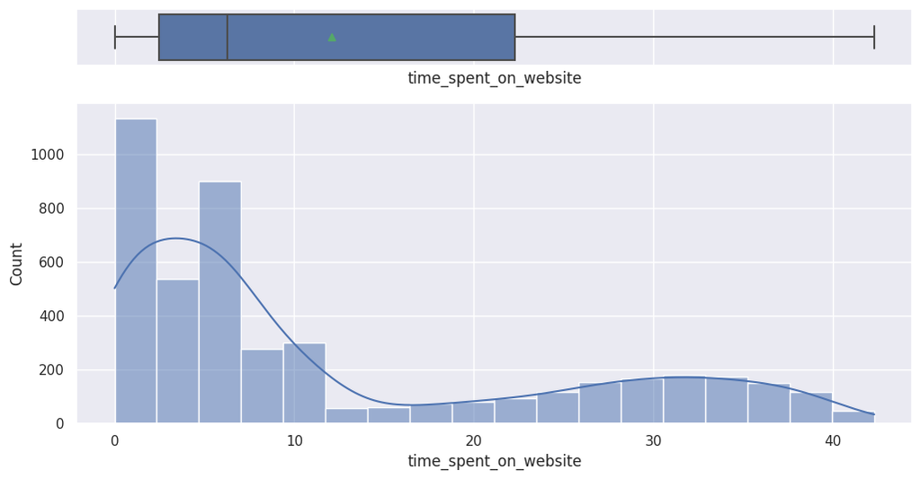

```python
# univariate analysis for "time_spent_on_website" variable
hist_box(df,'time_spent_on_website')
```

Observations

- The distribution of the "time_spent_on_website" parameter is right-skewed.
- This distribution is bi-modal with a large peak, ~700, betwen 0 to 6 minutes of time on the website, and there is a second smaller peak, ~200, around approximately 35 minutes of time on the website.
- The boxplot confirms that there are no outliers in the "time_spent_on_website" variable.

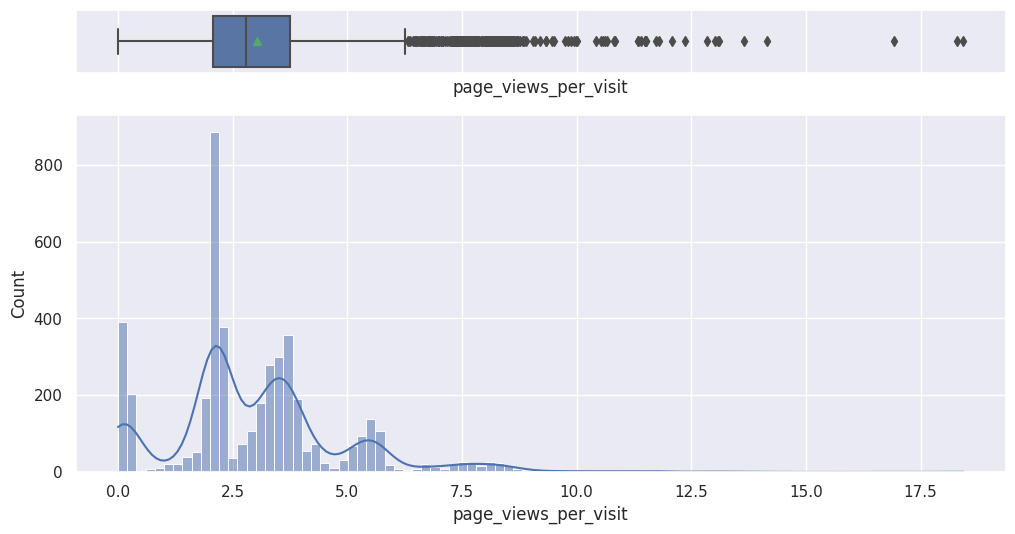

```python
# univariate analysis for "page_views_per_visit" variable
hist_box(df,'page_views_per_visit')
```

Observations

- The distribution of the "page_views_per_visit" parameter is right-skewed.
- This distribution is multi-modal with approximately five peaks.
- Most data points appear to be between 0 and 15 page views per visit.
- There are several data points in the region on the right of the boxplot that may be considered outliers. To investigate, we will look at how many extreme values there are.

```python
# checking amount of data points with greater than 15 page views per visit
df[df.page_views_per_visit>15]
```

|  | age | current_occupation | first_interaction | profile_completed | website_visits | time_spent_on_website | page_views_per_visit | last_activity | print_media_type1 | print_media_type2 | digital_media | educational_channels | referral | status |
| --- | --- | --- | --- | --- | --- | --- | --- | --- | --- | --- | --- | --- | --- | --- |
| 4 | 23 | Student | Website | High | 4 | 10.000000 | 16.914 | Email Activity | No | No | No | No | No | Unpaid Customer |
| 32 | 58 | Professional | Mobile App | High | 12 | 19.183333 | 18.434 | Phone Activity | No | No | No | Yes | No | Unpaid Customer |
| 268 | 57 | Professional | Mobile App | Medium | 3 | 16.816667 | 18.302 | Phone Activity | No | No | No | No | No | Unpaid Customer |

Observations:

- There are just three observations with more than 15 page views per visit.
- Thus, these observations can be considered as outliers.

```python
# removing the three outliers from "page_views_per_visit"
df.drop(index=df[df.page_views_per_visit>15].index,inplace=True)
```

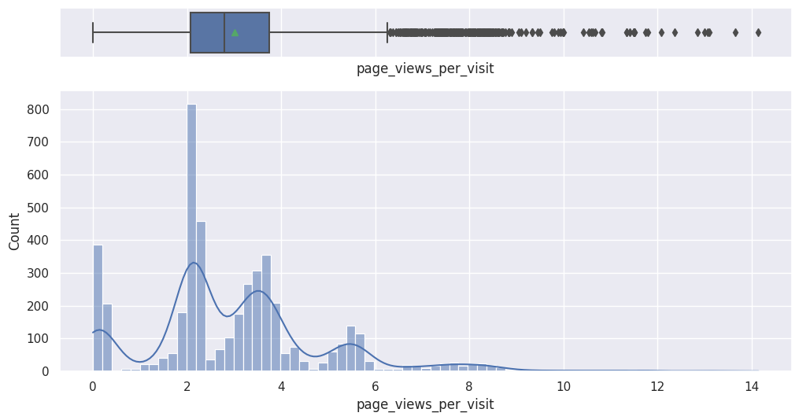

```python
# exploring the univariate analysis again for page_views_per_visit, after removing outliers
# univariate analysis for "page_views_per_visit" variable
hist_box(df,'page_views_per_visit')
```

Observations

- The distribution remains multimodal.
- There are fewer extreme outliers on the right side of the box plot.

### Univarite Analysis - Categorical Variables

List of categorical variables, for reference.

1. current_occupation
2. first_interaction
3. profile_completed
4. last_activity
5. print_media_type1
6. print_media_type2
7. digital_media
8. educational_channels
9. referral
10. status

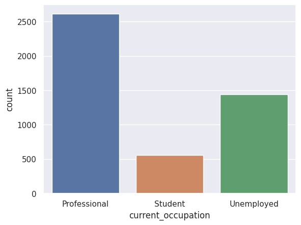

```python
# univariate analysis for "current_occupation" variable
sns.countplot(x = df['current_occupation'])
plt.show()
```

```python
# finding the percentages of each category
df['current_occupation'].value_counts(normalize=True)
```

```
Professional    0.567151
Unemployed      0.312649
Student         0.120200
Name: current_occupation, dtype: float64
```

Oberervations

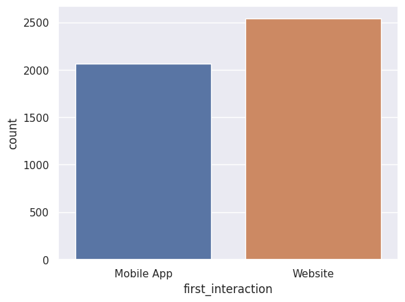

```python
# univariate analysis for "first_interaction" variable
sns.countplot(x = df['first_interaction'])
plt.show()
```

```python
# finding the percentages of each category
df['first_interaction'].value_counts(normalize=True)
```

```
Website       0.551313
Mobile App    0.448687
Name: first_interaction, dtype: float64
```

Oberervations

- Approximately 55% of leads first interacted with ExtraaLearn via website.
- Approximately 45% of leads first interacted with ExtraaLearn via mobile app.

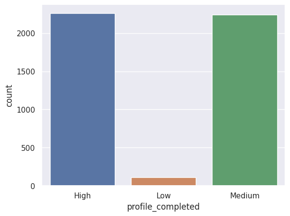

```python
# univariate analysis for "profile_completed" variable
sns.countplot(x = df['profile_completed'])
plt.show()
```

```python
# finding the percentages of each category
df['profile_completed'].value_counts(normalize=True)
```

```
High      0.490779
Medium    0.486006
Low       0.023215
Name: profile_completed, dtype: float64
```

Observations

- The leads are roughly split in half between high completion and medium completion.
- Only approximately 2% of leads have low profile completion.

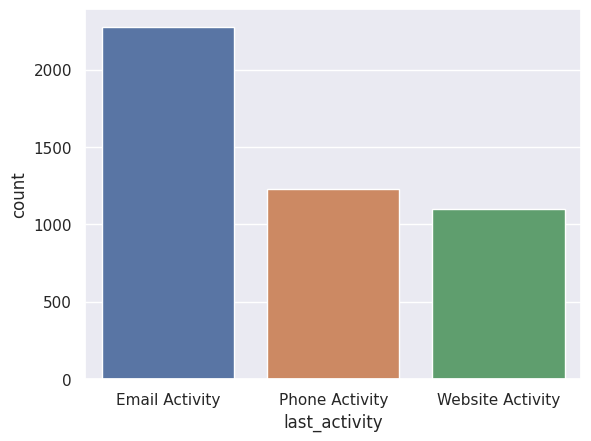

```python
# univariate analysis for "last_activity" variable
sns.countplot(x = df['last_activity'])
plt.show()
```

```python
# finding the percentages of each category
df['last_activity'].value_counts(normalize=True)
```

```
Email Activity      0.494033
Phone Activity      0.267303
Website Activity    0.238663
Name: last_activity, dtype: float64
```

Oberservations

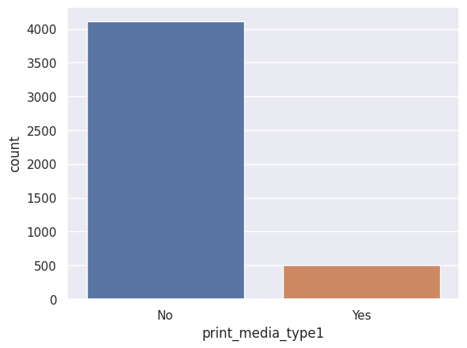

```python
# univariate analysis for "print_media_type1" variable, which represents leads who saw the add via newspaper
sns.countplot(x = df['print_media_type1'])
plt.show()
```

```python
# finding the percentages of each category
df['print_media_type1'].value_counts(normalize=True)
```

```
No     0.892167
Yes    0.107833
Name: print_media_type1, dtype: float64
```

Observations

- Most (89%) of leads did not see the ad in the newspaper.
- Only 11% of leads did se the ad in the newspaper.

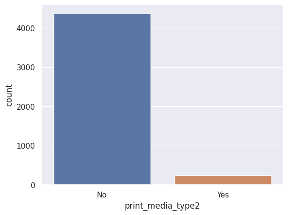

```python
# univariate analysis for "print_media_type2" variable, which represents leads who saw the add via magazine
sns.countplot(x = df['print_media_type2'])
plt.show()
```

```python
# finding the percentages of each category
df['print_media_type2'].value_counts(normalize=True)
```

```
No     0.949447
Yes    0.050553
Name: print_media_type2, dtype: float64
```

Observations

- Most (95%) of leads did not see the ad in the magazine
- Only (5%) did see the ad in the magazine

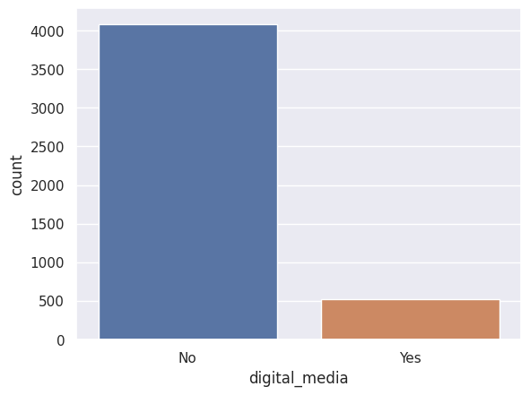

```python
# univariate analysis for "digital_media" variable
sns.countplot(x = df['digital_media'])
plt.show()
```

```python
# finding the percentages of each category
df['digital_media'].value_counts(normalize=True)
```

```
No     0.885658
Yes    0.114342
Name: digital_media, dtype: float64
```

Observations

- Most of the leads (89%) did not see the ad on digital media platforms.
- Only 11% of leads did see the ad on digital media platforms.

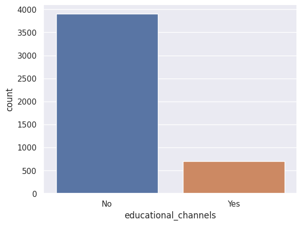

```python
# univariate analysis for "educational_channels" variable
sns.countplot(x = df['educational_channels'])
plt.show()
```

```python
# finding the percentages of each category
df['educational_channels'].value_counts(normalize=True)
```

```
No     0.847255
Yes    0.152745
Name: educational_channels, dtype: float64
```

Observations

- Most (85%) of leads did not see the ad via educational channels.
- Only 15% of leads did see the ad via educational channels.

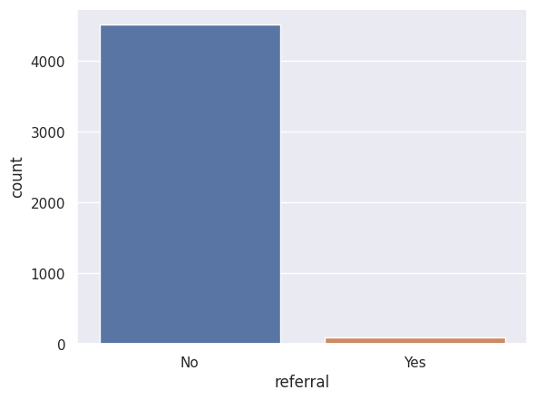

```python
# univariate analysis for "referral" variable
sns.countplot(x = df['referral'])
plt.show()
```

```python
# finding the percentages of each category
df['referral'].value_counts(normalize=True)
```

```
No     0.979822
Yes    0.020178
Name: referral, dtype: float64
```

Observations

- Most (98%) of leads did not hear about ExtraaLearn through a reference.
- Only 2% of leads heard about ExtraaLearn through a reference.

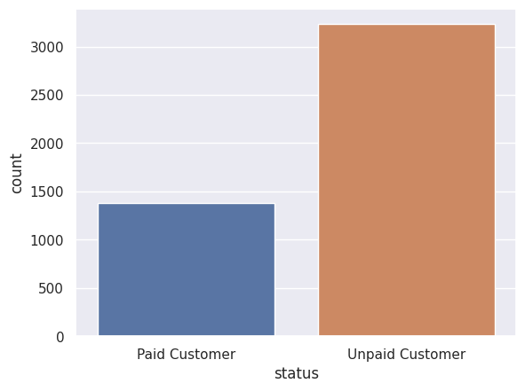

```python
# univariate analysis for "status" variable
sns.countplot(x = df['status'])
plt.show()
```

```python
# finding the percentages of each category
df['status'].value_counts(normalize=True)
```

```
Unpaid Customer    0.701237
Paid Customer      0.298763
Name: status, dtype: float64
```

Observations

- 30% of leads have converted to being a paid customer.
- 70% of leads are unpaid customers.

### Bivariate Analysis - Numerical Variables

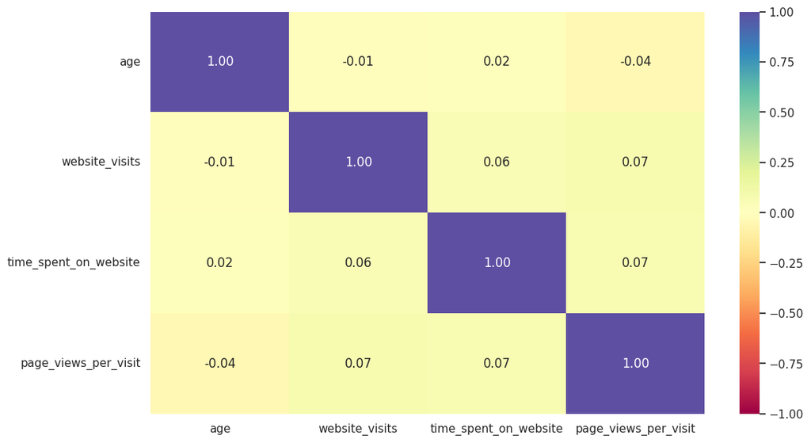

```python
# using heat map to find and visualize the correlation matrix for the numerical variables
cols_list = df.select_dtypes(include=np.number).columns.tolist()

plt.figure(figsize=(12, 7))
sns.heatmap(data[cols_list].corr(), annot=True, vmin=-1, vmax=1, fmt=".2f", cmap="Spectral")
plt.show()
```

Observations

- According to this heat map, no two variables in the heat map above appear to have a high correlation between them.

```python
# Mean of numerical variables grouped by status
df.groupby(['status'])[cols_list].mean()
```

| status | age | website_visits | time_spent_on_website | page_views_per_visit |
| --- | --- | --- | --- | --- |
| Paid Customer | 48.663762 | 3.538126 | 17.806633 | 3.027050 |
| Unpaid Customer | 45.152228 | 3.576423 | 9.618379 | 3.011941 |

Observations

- The average age of a paid customer is approximately 3.5 years older than unpaid customers.
- The average amount of website visits does not materially differ between paid and unpaid customers.
- The average amount of time that a paid customer spends on the website is nearly double as compared to unpaid customers.
- The average amount of page views per visit does not materially differ between paid and unpaid customers.

### Bivariate Analysis - Categorical Variables

```python
# defining the stacked_barplot() function to help analyze how the target variable varies across predictor categories
def stacked_barplot(df,predictor,target,figsize=(10,6)):
  (pd.crosstab(df[predictor],df[target],normalize='index')*100).plot(kind='bar',figsize=figsize,stacked=True)
  plt.legend(loc="lower right")
  plt.ylabel(target)
```

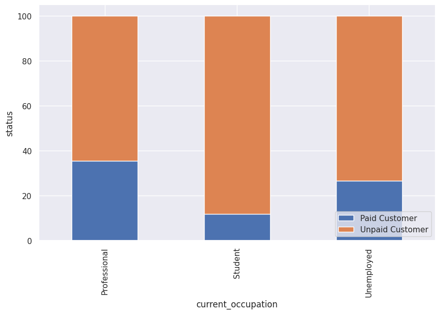

```python
# bivariate analysis with status and current_occupation
stacked_barplot(df, "current_occupation", "status")
```

Observations

- Students have the smallest percentage of paid customers.
- There is some variation between percentage of paid customers in each occupation category, so this may be a helpful variable in the ML model.

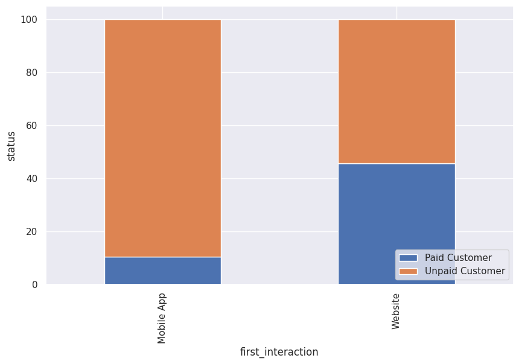

```python
# bivariate analysis with status and first_interaction
stacked_barplot(df, "first_interaction", "status" )
```

Observations

- The leads that first interact with ExtraaLearn via website are more likely to end up as a paid customer than those with the first interaction on the mobile app.

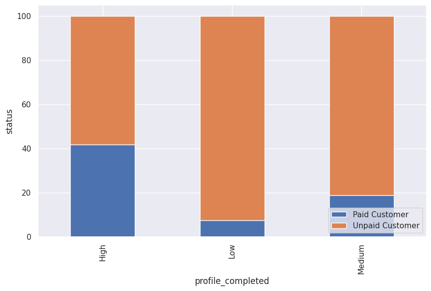

```python
# bivariate analysis with status and profile_completed
stacked_barplot(df, "profile_completed", "status" )
```

Observations

- Over 40% of the leads who have a high level of profile completion become paid customers.
- The leads who have a low level of profile completion are least likely to become paid customers.

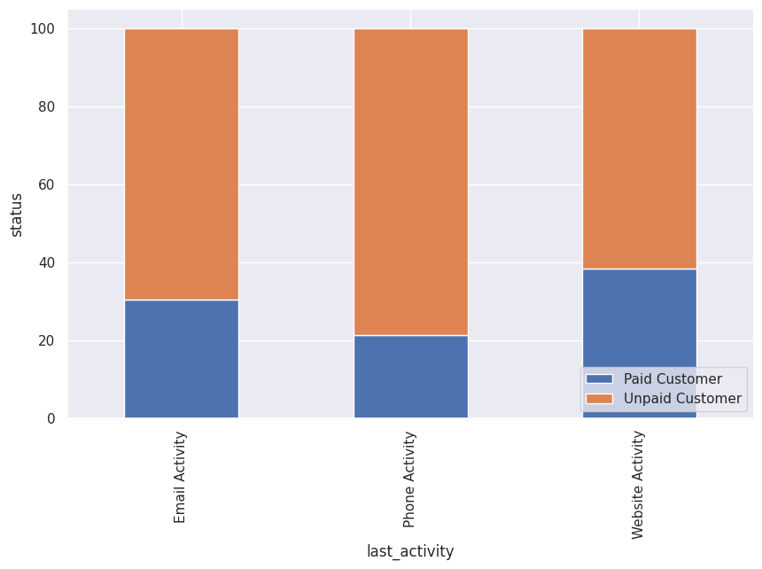

```python
# bivariate analysis with status and last_activity
stacked_barplot(df, "last_activity", "status" )
```

Observations

- Each of the three types of activities are correlated with approximately 20-40% of leads becoming paid customers.
- There is not much variance between the three activities, but website does have the highest percentage of paid customers.

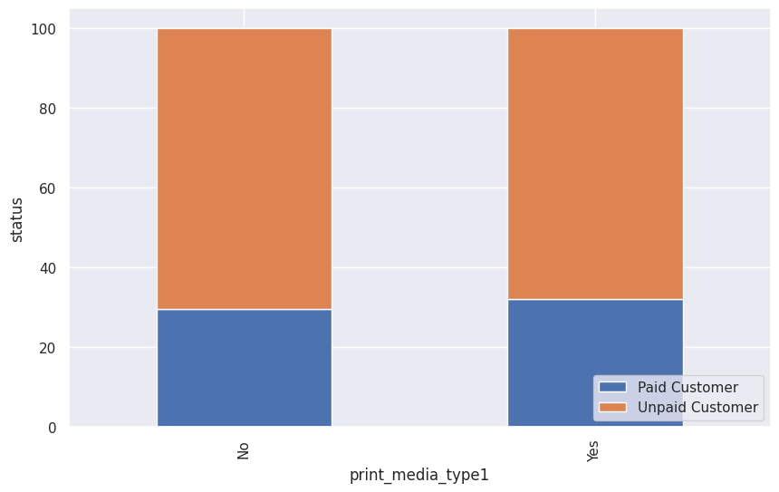

```python
# bivariate analysis with status and print_media_type1, which is via newspaper
stacked_barplot(df, "print_media_type1", "status" )
```

Observations

- Whether the lead has seen the ad in the newspaper or not, the lead has roughly the same likelihood of being a paid customer (~30%).
- Given this data, print_media_type1 does not have a high influence on whether a lead becomes a paid customer.

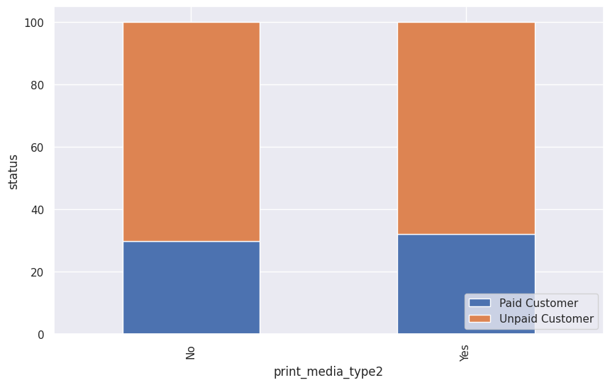

```python
# bivariate analysis with status and print_media_type2, which is via magazine
stacked_barplot(df, "print_media_type2", "status")
```

Observations

- Whether the lead has seen the ad in the magazine or not, the lead has roughly the same likelihood of being a paid customer (~30%).
- Given this data, print_media_type2 does not have a high influence on whether a lead becomes a paid customer.

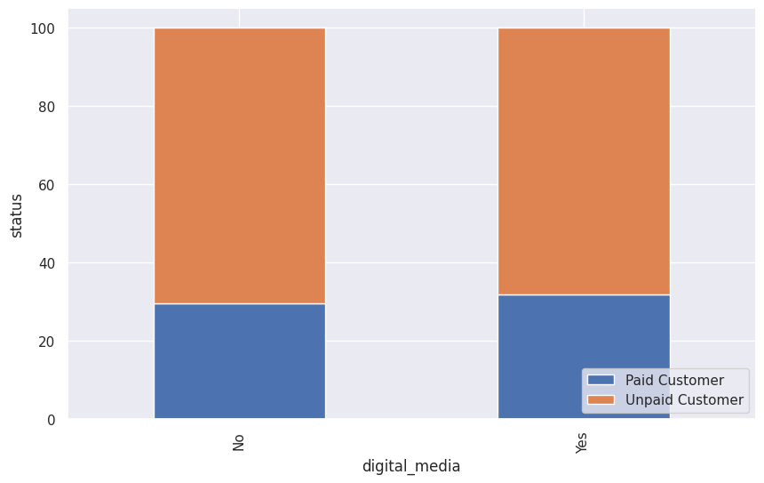

```python
# bivariate analysis with status and digital_media
stacked_barplot(df, "digital_media", "status")
```

Observations

- Whether the lead has seen the ad in digital media or not, the lead has roughly the same likelihood of being a paid customer (~30%).
- Given this data, digital_media does not have a high influence on whether a lead becomes a paid customer.

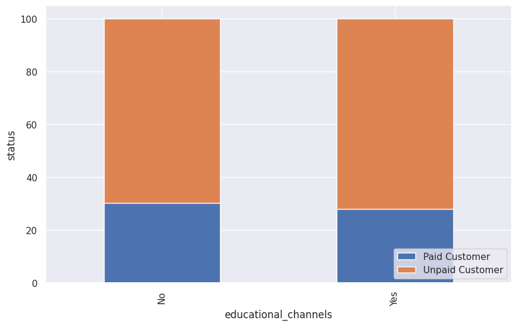

```python
# bivariate analysis with status and educational_channels
stacked_barplot(df, "educational_channels", "status")
```

Observations

- Whether the lead has seen the ad in educational channels or not, the lead has roughly the same likelihood of being a paid customer (~30%).
- Given this data, educational_channels does not have a high influence on whether a lead becomes a paid customer.

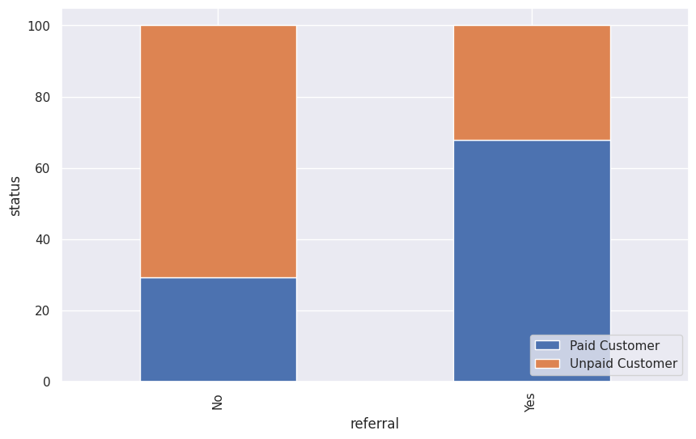

```python
# bivariate analysis with status and referral
stacked_barplot(df, "referral", "status")
```

Observations

- The leads who have heard about ExtraaLearn via a referral have a high likelihood of becoming a paid customer (~70%).
- By comparison, those without a referral are only ~30% likely to become a paid customer.
- The referral variable may be a helpful tool for the ML model.

### Summary

Based on the above preliminary analysis, it seems as though the following variables are **unlikely to influence** whether a lead will become a paid customer or not:

- website_visits
- page_views_per_visit
- print_media_type1
- print_media_type2
- digital_media
- educational_channels

However, the ML model will tell us more.

## Data Preprocessing

- Missing value treatment (if needed) **N/A**
- Feature engineering (if needed) **See above**
- Outlier detection and treatment (if needed) **See above**
- Preparing data for modeling **Below**
- Any other preprocessing steps (if needed) **See above**

```python
# separating target variable and other variables
X = df.drop(columns='status')
Y = df['status']
```

```python
# converting data types of binary categorical columns to float data types in the X dataframe

# for "first_interaction"
X.first_interaction = X.first_interaction.replace('Website','0') # converting string to contain number
X.first_interaction = X.first_interaction.replace('Mobile App','1') # converting string to contain number
X.first_interaction = X.first_interaction.astype('float') # changing data type

# for "print_media_type1"
X.print_media_type1 = X.print_media_type1.replace('No','0') # converting string to contain number
X.print_media_type1 = X.print_media_type1.replace('Yes','1') # converting string to contain number
X.print_media_type1 = X.print_media_type1.astype('float') # changing data type

# for "print_media_type2"
X.print_media_type2 = X.print_media_type2.replace('No','0') # converting string to contain number
X.print_media_type2 = X.print_media_type2.replace('Yes','1') # converting string to contain number
X.print_media_type2 = X.print_media_type2.astype('float') # changing data type

# for "digital_media"
X.digital_media = X.digital_media.replace('No','0') # converting string to contain number
X.digital_media = X.digital_media.replace('Yes','1') # converting string to contain number
X.digital_media = X.digital_media.astype('float') # changing data type

# for "educational_channels"
X.educational_channels = X.educational_channels.replace('No','0') # converting string to contain number
X.educational_channels = X.educational_channels.replace('Yes','1') # converting string to contain number
X.educational_channels = X.educational_channels.astype('float') # changing data type

# for "referral"
X.referral = X.referral.replace('No','0') # converting string to contain number
X.referral = X.referral.replace('Yes','1') # converting string to contain number
X.referral = X.referral.astype('float') # changing data type

# for "age"
X.age = X.age.astype('float') # changing data type

# for "website_visits"
X.website_visits = X.website_visits.astype('float') # changing data type

# checking that data types are updated
X.info() # dataframe summary
```

```
<class 'pandas.core.frame.DataFrame'>
Int64Index: 4609 entries, 0 to 4611
Data columns (total 13 columns):
 #   Column                 Non-Null Count  Dtype
---  ------                 --------------  -----
 0   age                    4609 non-null   float64
 1   current_occupation     4609 non-null   category
 2   first_interaction      4609 non-null   float64
 3   profile_completed      4609 non-null   category
 4   website_visits         4609 non-null   float64
 5   time_spent_on_website  4609 non-null   float64
 6   page_views_per_visit   4609 non-null   float64
 7   last_activity          4609 non-null   category
 8   print_media_type1      4609 non-null   float64
 9   print_media_type2      4609 non-null   float64
 10  digital_media          4609 non-null   float64
 11  educational_channels   4609 non-null   float64
 12  referral               4609 non-null   float64
dtypes: category(3), float64(10)
memory usage: 410.0 KB
```

```python
# for "status"
Y = Y.replace('Unpaid Customer','0') # converting string to contain number
Y = Y.replace('Paid Customer','1') # converting string to contain number
Y = Y.astype('float') # changing data type

Y.info() # dataframe summary
```

```
<class 'pandas.core.series.Series'>
Int64Index: 4609 entries, 0 to 4611
Series name: status
Non-Null Count  Dtype
--------------  -----
4609 non-null   float64
dtypes: float64(1)
memory usage: 72.0 KB
```

```python
# Checking for missing values in Y
print(Y.isna().sum())
```

```
0
```

```python
# checking the first 5 rows of Y
Y.head()
```

```
0    1.0
1    0.0
2    0.0
3    1.0
5    0.0
Name: status, dtype: float64
```

- In the X data frame, there are 3 remaining categorical variables: "current_occupation", "profile_completed", and "last_activity". Since these variables are non-binary, dummy variables are to be created.

```python
#List of columns to create a dummy variables
col_dummy = ['current_occupation', 'profile_completed', 'last_activity']

#Encoding categorical varaibles
X = pd.get_dummies(X, columns=col_dummy)
```

```python
dummies = ['current_occupation_Professional', 'current_occupation_Student', 'current_occupation_Unemployed', 'profile_completed_High', 'profile_completed_Low', 'profile_completed_Medium', 'last_activity_Email Activity', 'last_activity_Phone Activity', 'last_activity_Website Activity']

for column in dummies:
    X[column] = X[column].astype('float')
```

```python
# Splitting the data into a 70% train and 30% test sets
X_train,X_test,Y_train,Y_test=train_test_split(X,Y,test_size=0.30,random_state=1,stratify=Y)
```

## EDA

**All data manipulation completed has already either been followed by a validation step and/or was completed prior to the first EDA, except for the "Preparing data for model" above, which will be checked below.**

```python
X.info()
```

```
<class 'pandas.core.frame.DataFrame'>
Int64Index: 4609 entries, 0 to 4611
Data columns (total 19 columns):
 #   Column                           Non-Null Count  Dtype
---  ------                           --------------  -----
 0   age                              4609 non-null   float64
 1   first_interaction                4609 non-null   float64
 2   website_visits                   4609 non-null   float64
 3   time_spent_on_website            4609 non-null   float64
 4   page_views_per_visit             4609 non-null   float64
 5   print_media_type1                4609 non-null   float64
 6   print_media_type2                4609 non-null   float64
 7   digital_media                    4609 non-null   float64
 8   educational_channels             4609 non-null   float64
 9   referral                         4609 non-null   float64
 10  current_occupation_Professional  4609 non-null   float64
 11  current_occupation_Student       4609 non-null   float64
 12  current_occupation_Unemployed    4609 non-null   float64
 13  profile_completed_High           4609 non-null   float64
 14  profile_completed_Low            4609 non-null   float64
 15  profile_completed_Medium         4609 non-null   float64
 16  last_activity_Email Activity     4609 non-null   float64
 17  last_activity_Phone Activity     4609 non-null   float64
 18  last_activity_Website Activity   4609 non-null   float64
dtypes: float64(19)
memory usage: 720.2 KB
```

```python
X.head()
```

|  | age | first_interaction | website_visits | time_spent_on_website | page_views_per_visit | print_media_type1 | print_media_type2 | digital_media | educational_channels | referral | current_occupation_Professional | current_occupation_Student | current_occupation_Unemployed | profile_completed_High | profile_completed_Low | profile_completed_Medium | last_activity_Email Activity | last_activity_Phone Activity | last_activity_Website Activity |
| --- | --- | --- | --- | --- | --- | --- | --- | --- | --- | --- | --- | --- | --- | --- | --- | --- | --- | --- | --- |
| 0 | 57.0 | 0.0 | 7.0 | 27.316667 | 1.861 | 1.0 | 0.0 | 1.0 | 0.0 | 0.0 | 0.0 | 0.0 | 1.0 | 1.0 | 0.0 | 0.0 | 0.0 | 0.0 | 1.0 |
| 1 | 56.0 | 1.0 | 2.0 | 1.383333 | 0.320 | 0.0 | 0.0 | 0.0 | 1.0 | 0.0 | 1.0 | 0.0 | 0.0 | 0.0 | 0.0 | 1.0 | 0.0 | 0.0 | 1.0 |
| 2 | 52.0 | 0.0 | 3.0 | 5.500000 | 0.074 | 0.0 | 0.0 | 1.0 | 0.0 | 0.0 | 1.0 | 0.0 | 0.0 | 0.0 | 0.0 | 1.0 | 0.0 | 0.0 | 1.0 |
| 3 | 53.0 | 0.0 | 4.0 | 7.733333 | 2.057 | 0.0 | 0.0 | 0.0 | 0.0 | 0.0 | 0.0 | 0.0 | 1.0 | 1.0 | 0.0 | 0.0 | 0.0 | 0.0 | 1.0 |
| 5 | 50.0 | 1.0 | 4.0 | 3.533333 | 5.682 | 0.0 | 0.0 | 0.0 | 1.0 | 0.0 | 0.0 | 0.0 | 1.0 | 1.0 | 0.0 | 0.0 | 0.0 | 1.0 | 0.0 |

```python
X.tail()
```

|  | age | first_interaction | website_visits | time_spent_on_website | page_views_per_visit | print_media_type1 | print_media_type2 | digital_media | educational_channels | referral | current_occupation_Professional | current_occupation_Student | current_occupation_Unemployed | profile_completed_High | profile_completed_Low | profile_completed_Medium | last_activity_Email Activity | last_activity_Phone Activity | last_activity_Website Activity |
| --- | --- | --- | --- | --- | --- | --- | --- | --- | --- | --- | --- | --- | --- | --- | --- | --- | --- | --- | --- |
| 4607 | 35.0 | 1.0 | 15.0 | 6.000000 | 2.170 | 0.0 | 0.0 | 0.0 | 1.0 | 0.0 | 0.0 | 0.0 | 1.0 | 0.0 | 0.0 | 1.0 | 0.0 | 1.0 | 0.0 |
| 4608 | 55.0 | 1.0 | 8.0 | 38.783333 | 5.393 | 0.0 | 0.0 | 0.0 | 0.0 | 0.0 | 1.0 | 0.0 | 0.0 | 0.0 | 0.0 | 1.0 | 1.0 | 0.0 | 0.0 |
| 4609 | 58.0 | 0.0 | 2.0 | 3.533333 | 2.692 | 0.0 | 0.0 | 0.0 | 0.0 | 0.0 | 1.0 | 0.0 | 0.0 | 1.0 | 0.0 | 0.0 | 1.0 | 0.0 | 0.0 |
| 4610 | 57.0 | 1.0 | 1.0 | 2.566667 | 3.879 | 1.0 | 0.0 | 0.0 | 0.0 | 0.0 | 1.0 | 0.0 | 0.0 | 0.0 | 0.0 | 1.0 | 0.0 | 0.0 | 1.0 |
| 4611 | 55.0 | 0.0 | 4.0 | 38.166667 | 2.075 | 0.0 | 0.0 | 0.0 | 0.0 | 0.0 | 1.0 | 0.0 | 0.0 | 0.0 | 0.0 | 1.0 | 0.0 | 1.0 | 0.0 |

```python
Y.head()
```

```
0    1.0
1    0.0
2    0.0
3    1.0
5    0.0
Name: status, dtype: float64
```

```python
Y.tail()
```

```
4607    0.0
4608    0.0
4609    1.0
4610    0.0
4611    0.0
Name: status, dtype: float64
```

Observations

- "status" is not a part of independent variable dataset X, as expected.
- "status" is the only variable in Y, as expected.
- All datatypes in X and Y are converted to float.

```python
X_train.info()
```

```
<class 'pandas.core.frame.DataFrame'>
Int64Index: 3226 entries, 541 to 3232
Data columns (total 19 columns):
 #   Column                           Non-Null Count  Dtype
---  ------                           --------------  -----
 0   age                              3226 non-null   float64
 1   first_interaction                3226 non-null   float64
 2   website_visits                   3226 non-null   float64
 3   time_spent_on_website            3226 non-null   float64
 4   page_views_per_visit             3226 non-null   float64
 5   print_media_type1                3226 non-null   float64
 6   print_media_type2                3226 non-null   float64
 7   digital_media                    3226 non-null   float64
 8   educational_channels             3226 non-null   float64
 9   referral                         3226 non-null   float64
 10  current_occupation_Professional  3226 non-null   float64
 11  current_occupation_Student       3226 non-null   float64
 12  current_occupation_Unemployed    3226 non-null   float64
 13  profile_completed_High           3226 non-null   float64
 14  profile_completed_Low            3226 non-null   float64
 15  profile_completed_Medium         3226 non-null   float64
 16  last_activity_Email Activity     3226 non-null   float64
 17  last_activity_Phone Activity     3226 non-null   float64
 18  last_activity_Website Activity   3226 non-null   float64
dtypes: float64(19)
memory usage: 504.1 KB
```

```python
X_test.info()
```

```
<class 'pandas.core.frame.DataFrame'>
Int64Index: 1383 entries, 2362 to 1847
Data columns (total 19 columns):
 #   Column                           Non-Null Count  Dtype
---  ------                           --------------  -----
 0   age                              1383 non-null   float64
 1   first_interaction                1383 non-null   float64
 2   website_visits                   1383 non-null   float64
 3   time_spent_on_website            1383 non-null   float64
 4   page_views_per_visit             1383 non-null   float64
 5   print_media_type1                1383 non-null   float64
 6   print_media_type2                1383 non-null   float64
 7   digital_media                    1383 non-null   float64
 8   educational_channels             1383 non-null   float64
 9   referral                         1383 non-null   float64
 10  current_occupation_Professional  1383 non-null   float64
 11  current_occupation_Student       1383 non-null   float64
 12  current_occupation_Unemployed    1383 non-null   float64
 13  profile_completed_High           1383 non-null   float64
 14  profile_completed_Low            1383 non-null   float64
 15  profile_completed_Medium         1383 non-null   float64
 16  last_activity_Email Activity     1383 non-null   float64
 17  last_activity_Phone Activity     1383 non-null   float64
 18  last_activity_Website Activity   1383 non-null   float64
dtypes: float64(19)
memory usage: 216.1 KB
```

```python
Y_train.info()
```

```
<class 'pandas.core.series.Series'>
Int64Index: 3226 entries, 541 to 3232
Series name: status
Non-Null Count  Dtype
--------------  -----
3226 non-null   float64
dtypes: float64(1)
memory usage: 50.4 KB
```

```python
Y_test.info()
```

```
<class 'pandas.core.series.Series'>
Int64Index: 1383 entries, 2362 to 1847
Series name: status
Non-Null Count  Dtype
--------------  -----
1383 non-null   float64
dtypes: float64(1)
memory usage: 21.6 KB
```

- The 70-30 split appears to have been appropriately completed for both X and Y.

## Building a Decision Tree model

```python
# function for printing classification report and confusion matrix

def metrics_score(actual, predicted):
    print(classification_report(actual, predicted))

    cm = confusion_matrix(actual, predicted)

    plt.figure(figsize = (8, 5))

    sns.heatmap(cm, annot = True,  fmt = '.2f', xticklabels = ['Unpaid', 'Paid'], yticklabels = ['Unpaid', 'Paid'])

    plt.ylabel('Actual')

    plt.xlabel('Predicted')

    plt.show()
```

```python
# using training data to fit the decision tree classifier
model_dt = DecisionTreeClassifier(random_state=1)
model_dt.fit(X_train, Y_train)
```

```
DecisionTreeClassifier(random_state=1)
```

```
              precision    recall  f1-score   support

         0.0       1.00      1.00      1.00      2262
         1.0       1.00      1.00      1.00       964

    accuracy                           1.00      3226
   macro avg       1.00      1.00      1.00      3226
weighted avg       1.00      1.00      1.00      3226
```

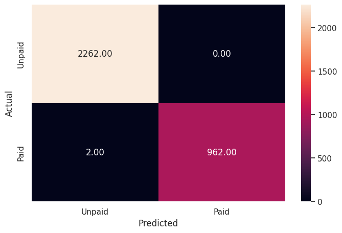

```python
# using the training data to check the model's performance
pred_train_dt = model_dt.predict(X_train)
metrics_score(Y_train, pred_train_dt)
```

Observations

- Minimal errors on the training set.
- The model has performed very well on the training dataset.
- However, this does not necessarily equate to a strong model.
- To better understand this, we will check the performance on test data to see if the model is overfitting.

```
              precision    recall  f1-score   support

         0.0       0.87      0.86      0.86       970
         1.0       0.68      0.69      0.68       413

    accuracy                           0.81      1383
   macro avg       0.77      0.77      0.77      1383
weighted avg       0.81      0.81      0.81      1383
```

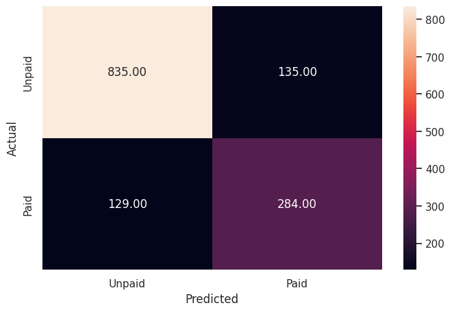

```python
# using the test data to check the model's performance
pred_test_dt = model_dt.predict(X_test)
metrics_score(Y_test, pred_test_dt)
```

Observations

```python
# listing the feature importance

print(pd.DataFrame(model_dt.feature_importances_, columns = ["Importance"], index = X_train.columns).sort_values(by = 'Importance', ascending = False))
```

```
                                 Importance
time_spent_on_website              0.254071
first_interaction                  0.191456
page_views_per_visit               0.103162
age                                0.101274
profile_completed_High             0.085737
website_visits                     0.066930
current_occupation_Professional    0.065357
last_activity_Phone Activity       0.035970
last_activity_Website Activity     0.031980
print_media_type1                  0.010810
last_activity_Email Activity       0.009982
educational_channels               0.008433
current_occupation_Unemployed      0.007700
digital_media                      0.007593
profile_completed_Low              0.006617
referral                           0.005771
print_media_type2                  0.005047
profile_completed_Medium           0.002110
current_occupation_Student         0.000000
```

Observations

## Do we need to prune the tree?

Pruning the tree could be helpful, but is not absolutely necessary. We can see which features are the most important within this model by the above list.

## Building a Random Forest model

```python
# fitting the Random Forest classifier on the training data
rf_estimator = RandomForestClassifier( random_state = 1)

rf_estimator.fit(X_train, Y_train)
```

```
RandomForestClassifier(random_state=1)
```

```
              precision    recall  f1-score   support

         0.0       1.00      1.00      1.00      2262
         1.0       1.00      1.00      1.00       964

    accuracy                           1.00      3226
   macro avg       1.00      1.00      1.00      3226
weighted avg       1.00      1.00      1.00      3226
```

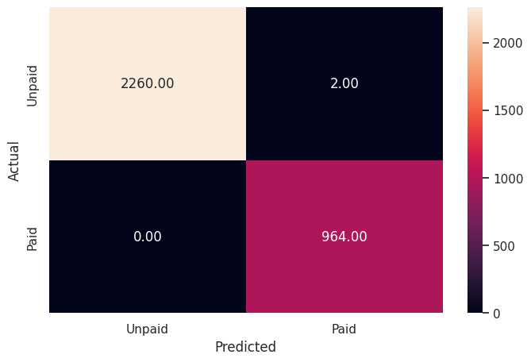

```python
# checking performance on the training data
Y_pred_train_rf = rf_estimator.predict(X_train)

metrics_score(Y_train, Y_pred_train_rf)
```

Observations

- Minimal errors on the training set.
- The RF model has performed very well on the training dataset.
- However, this does not necessarily equate to a strong model.
- To better understand this, we will check the performance on test data.

```
              precision    recall  f1-score   support

         0.0       0.89      0.91      0.90       970
         1.0       0.78      0.74      0.76       413

    accuracy                           0.86      1383
   macro avg       0.83      0.82      0.83      1383
weighted avg       0.86      0.86      0.86      1383
```

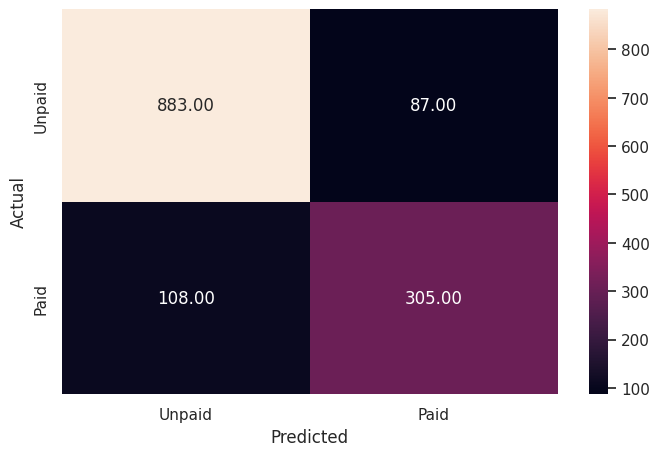

```python
# checking performance on the testing data
Y_pred_test_rf = rf_estimator.predict(X_test)

metrics_score(Y_test, Y_pred_test_rf)
```

Observations

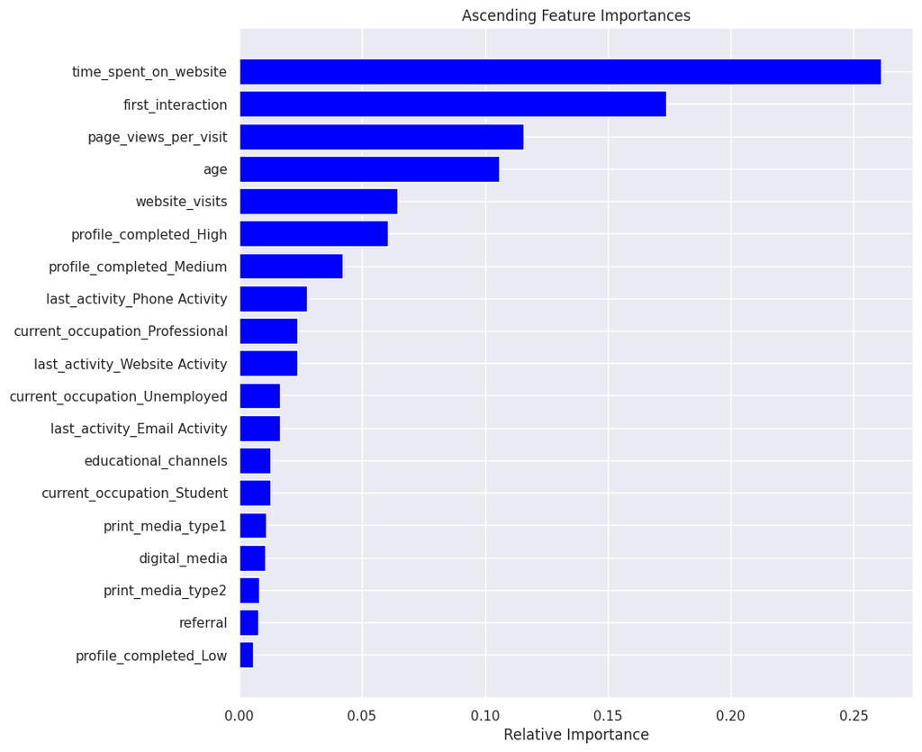

```python
# plotting the feature importance
importances = rf_estimator.feature_importances_
features = list(X.columns)
indices = np.argsort(importances)

plt.figure(figsize = (10, 10))

plt.title('Ascending Feature Importances')

plt.barh(range(len(indices)), importances[indices], color = 'blue', align = 'center')

plt.yticks(range(len(indices)), [features[i] for i in indices])

plt.xlabel('Relative Importance')

plt.show()
```

Observations

## Do we need to prune the tree?

No, we do not need to prune the tree.

## Actionable Insights and Recommendations

Actionable Insights

Recommendations